# Chapter 4

# Libraries

```r
library(magrittr)
library(tidyverse)
library(dplyr)
library(psych)
library(smacof)
library(ggplot2)
library(cmdpref)
```

# Example 1 (Airlines Data)

- Data is distances between pairs of US cities
- Use MDS to obtain map of cities
- Small values are similar

```r
airlines<- read.csv("~/MSTAT/STAT8019_Marketing_Analytics/lecture notes/chap4r/airlines.csv", row.names = 1, header = T)

airlines
```

|  | x1 | x2 | x3 | x4 | x5 | x6 | x7 | x8 | x9 | x10 | x11 | x12 |
| --- | --- | --- | --- | --- | --- | --- | --- | --- | --- | --- | --- | --- |
| atlanta | 0 | NA | NA | NA | NA | NA | NA | NA | NA | NA | NA | NA |
| boston | 1068 | 0 | NA | NA | NA | NA | NA | NA | NA | NA | NA | NA |
| cincinnati | 461 | 867 | 0 | NA | NA | NA | NA | NA | NA | NA | NA | NA |
| columbus | 549 | 769 | 107 | 0 | NA | NA | NA | NA | NA | NA | NA | NA |
| dallas | 805 | 1819 | 943 | 1050 | 0 | NA | NA | NA | NA | NA | NA | NA |
| indianapolis | 508 | 941 | 108 | 172 | 882 | 0 | NA | NA | NA | NA | NA | NA |
| little rock | 505 | 1494 | 618 | 725 | 325 | 562 | 0 | NA | NA | NA | NA | NA |
| los angeles | 2197 | 3052 | 2186 | 2245 | 1403 | 2080 | 1701 | 0 | NA | NA | NA | NA |
| memphis | 366 | 1355 | 502 | 586 | 464 | 436 | 137 | 1831 | 0 | NA | NA | NA |
| st. louis | 558 | 1178 | 338 | 409 | 645 | 234 | 353 | 1848 | 294 | 0 | NA | NA |

[output cut: 2 more lines]

**Solution**

- Attribute free (only distance)
- Transformation
  - Ratio is meaningful
  - Other transformation is possible

## Fit MDS

- Can vary the number of dimensions
- Small similar, large difference
- IF the other way round, need to convert, maybe use reciprocal

```r
#mds() multidimensional scaling
#delta= dissimilarity matrix
#ndim= number of dimensions
#type="ratio" ratio transformation
fit1<-mds(delta=airlines,ndim=1,type="ratio")
fit1
```

```
Call:
mds(delta = airlines, ndim = 1, type = "ratio")

Model: Symmetric SMACOF
Number of objects: 12
Stress-1 value: 0.191
Number of iterations: 2
```

```r
fit2<-mds(delta=airlines,ndim=2,type="ratio")
fit2
```

```
Call:
mds(delta = airlines, ndim = 2, type = "ratio")

Model: Symmetric SMACOF
Number of objects: 12
Stress-1 value: 0.013
Number of iterations: 7
```

```r
fit3<-mds(delta=airlines,ndim=3,type="ratio")
fit3
```

```
Call:
mds(delta = airlines, ndim = 3, type = "ratio")

Model: Symmetric SMACOF
Number of objects: 12
Stress-1 value: 0.014
Number of iterations: 20
```

```r
fit4<-mds(delta=airlines,ndim=4,type="ratio")
fit4
```

```
Call:
mds(delta = airlines, ndim = 4, type = "ratio")

Model: Symmetric SMACOF
Number of objects: 12
Stress-1 value: 0.014
Number of iterations: 23
```

### Stress Scree Plot

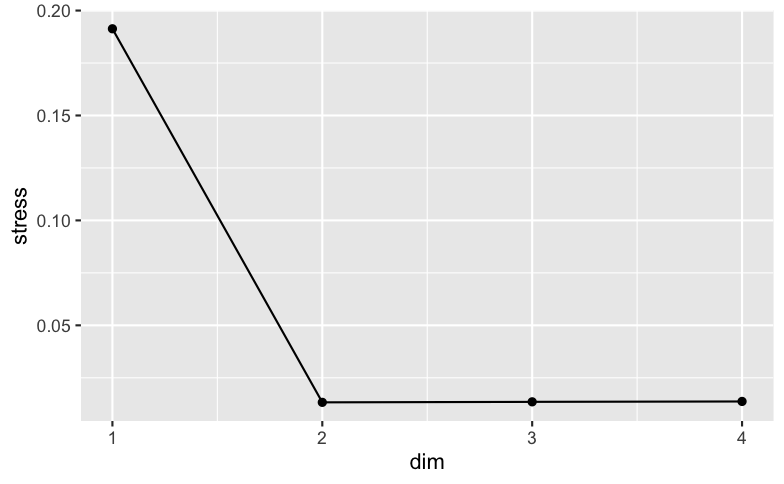

```r
#scree plot
stress<-data.frame(dim=1:4,stress=c(fit1$stress,fit2$stress,fit3$stress,fit4$stress))
ggplot(data=stress,aes(x=dim,y=stress))+
  geom_line()+
  geom_point()
```

- 2 dimensins are the best, lowest stress
- Not necessarily continue decreasing
- Similar to map, 2 dimensions are enough

## Coordinates

```r
#configuration
summary(fit2)
```

```
Configurations:
                  D1      D2
atlanta      -0.3701  0.1744
boston       -0.7926 -0.5058
cincinnati   -0.2663 -0.1539
columbus     -0.3069 -0.2140
dallas        0.1976  0.3487
indianapolis -0.1899 -0.1543
little rock   0.0079  0.2013
los angeles   1.2290  0.3340
memphis      -0.0874  0.1562
st. louis    -0.0436 -0.0612
spokane       1.1944 -0.5778
tampa        -0.5722  0.4524


Stress per point (in %):
     atlanta       boston   cincinnati     columbus       dallas
       18.94        11.38         3.94         1.50         3.11
indianapolis  little rock  los angeles      memphis    st. louis
        6.26         7.99         7.72         3.96         5.37
     spokane        tampa
       23.96         5.86
```

- Flip xy axis to flip for better illustration

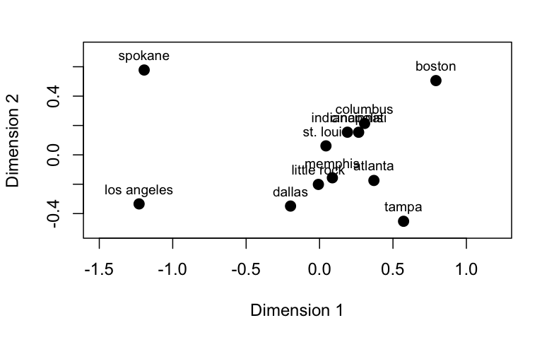

```r
#flip horizontally and vertically so as to be consistent with US map
fit2$conf<- -fit2$conf
#plot the configuration
plot(fit2,xlim=c(-1.5,1.2),ylim=c(-0.5,0.7),main="",cex=2)
```

### Divided (Ratio) Distance from coordinates

- Will return the ratio distance rather than the original absolute distance

```r
#derived distances
fit2$confdist
```

```
                atlanta     boston cincinnati   columbus     dallas
boston       0.80072078
cincinnati   0.34428816 0.63316851
columbus     0.39345687 0.56665523 0.07253778
dallas       0.59393131 1.30799059 0.68397089 0.75576300
indianapolis 0.37488784 0.69774642 0.07640526 0.13135052 0.63499800
little rock  0.37900742 1.06809871 0.44867674 0.52109067 0.24027826
los angeles  1.60702663 2.18906082 1.57279620 1.63066689 1.03142359
memphis      0.28334678 0.96727846 0.35797538 0.43036052 0.34394232
st. louis    0.40259024 0.87103418 0.24117460 0.30440165 0.47562100
spokane      1.73590634 1.98827959 1.52090142 1.54471225 1.36084015
tampa        0.34365728 0.98322152 0.67904787 0.71719992 0.77674285
             indianapolis little rock los angeles    memphis
boston
cincinnati
columbus
dallas
indianapolis
little rock    0.40690606
los angeles    1.50049569  1.22821991
memphis        0.32699855  0.10541558  1.32827088
st. louis      0.17339518  0.26744712  1.33251444 0.22170640
spokane        1.44754892  1.41935310  0.91241462 1.47700429
tampa          0.71710350  0.63209975  1.80500216 0.56811210
              st. louis    spokane
boston
cincinnati
columbus
dallas
indianapolis
little rock
los angeles
memphis
st. louis
spokane      1.34146133
tampa        0.73692822 2.04495133
```

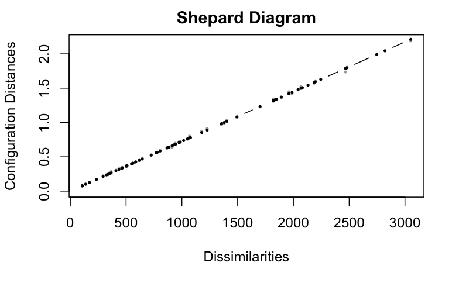

```r
#derived distances vs original distances
plot(fit2,plot.type="Shepard")
```

- Straight line implies what we observe and what we divide are consistent with each other

# Example 2 (Cars Data)

- ranking of 55 pairs
- 1 - 55
- Smaller rank is similar, larger rank is dissimilar

```r
cars<-read.csv("~/MSTAT/STAT8019_Marketing_Analytics/lecture notes/chap4r/cars.csv", header = TRUE,row.names=1)
cars
```

|  | x1 | x2 | x3 | x4 | x5 | x6 | x7 | x8 | x9 | x10 | x11 |
| --- | --- | --- | --- | --- | --- | --- | --- | --- | --- | --- | --- |
| Ford Mustang 6 | 0 | NA | NA | NA | NA | NA | NA | NA | NA | NA | NA |
| Mercury Cougar V8 | 8 | 0 | NA | NA | NA | NA | NA | NA | NA | NA | NA |
| Lincoln Continental V8 | 50 | 38 | 0 | NA | NA | NA | NA | NA | NA | NA | NA |
| Ford Thunderbird V8 | 31 | 9 | 11 | 0 | NA | NA | NA | NA | NA | NA | NA |
| Ford Falcon 6 | 12 | 33 | 55 | 44 | 0 | NA | NA | NA | NA | NA | NA |
| Chrysler Imperial V8 | 48 | 37 | 1 | 13 | 54 | 0 | NA | NA | NA | NA | NA |
| Jaguar | 36 | 22 | 23 | 16 | 53 | 26 | 0 | NA | NA | NA | NA |
| AMC Javelin V8 | 2 | 6 | 46 | 19 | 30 | 47 | 29 | 0 | NA | NA | NA |
| Plymouth Barracuda V8 | 5 | 4 | 41 | 25 | 28 | 40 | 35 | 3 | 0 | NA | NA |
| Buick Le Sabre V8 | 39 | 14 | 17 | 18 | 45 | 24 | 34 | 27 | 20 | 0 | NA |

[output cut: 1 more lines]

## `"interval"` Transformation

- D* = a + bD

```r
fit <- mds(cars, ndim = 2, type="interval")
summary(fit)
```

```
Configurations:
                            D1      D2
Ford Mustang 6         -0.5639  0.1548
Mercury Cougar V8      -0.0696  0.1973
Lincoln Continental V8  0.8660 -0.1519
Ford Thunderbird V8     0.4124  0.0915
Ford Falcon 6          -0.8414 -0.4303
Chrysler Imperial V8    0.8573 -0.2621
Jaguar                  0.5269  0.5788
AMC Javelin V8         -0.3619  0.2900
Plymouth Barracuda V8  -0.2960  0.0972
Buick Le Sabre V8       0.3028 -0.4282
Chevrolet Covair       -0.8326 -0.1371


Stress per point (in %):
        Ford Mustang 6      Mercury Cougar V8 Lincoln Continental V8
                  6.34                  11.90                   7.26
   Ford Thunderbird V8          Ford Falcon 6   Chrysler Imperial V8
                  5.73                  12.49                  10.27
                Jaguar         AMC Javelin V8  Plymouth Barracuda V8
                  4.73                   4.80                   7.52
     Buick Le Sabre V8       Chevrolet Covair
                 17.55                  11.41
```

```r
fit$stress
```

```
[1] 0.1040995
```

### Perceptual Plot

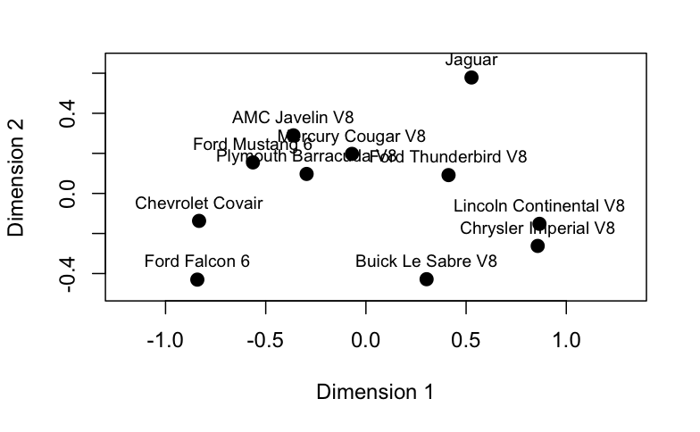

```r
plot(fit,xlim=c(-1.2,1.3),main="",cex=2)
```

## `"ordinal"` transformation

- Ordering of the data is meaningful
- Others such as difference, ratio, are not meaningful

```r
fit2 <- mds(cars, ndim = 2, type="ordinal")
summary(fit2)
```

```
Configurations:
                            D1      D2
Ford Mustang 6         -0.4996  0.1403
Mercury Cougar V8      -0.0590  0.0879
Lincoln Continental V8  0.9117 -0.0976
Ford Thunderbird V8     0.3466  0.0751
Ford Falcon 6          -0.9868 -0.3009
Chrysler Imperial V8    0.9265 -0.1340
Jaguar                  0.4953  0.5582
AMC Javelin V8         -0.3115  0.1952
Plymouth Barracuda V8  -0.2608 -0.0619
Buick Le Sabre V8       0.3103 -0.4270
Chevrolet Covair       -0.8726 -0.0354


Stress per point (in %):
        Ford Mustang 6      Mercury Cougar V8 Lincoln Continental V8
                  6.19                   2.84                  11.13
   Ford Thunderbird V8          Ford Falcon 6   Chrysler Imperial V8
                 20.60                  10.19                   1.66
                Jaguar         AMC Javelin V8  Plymouth Barracuda V8
                 15.79                   5.46                   8.49
     Buick Le Sabre V8       Chevrolet Covair
                 14.65                   2.99
```

```r
fit2$stress
```

```
[1] 0.03764154
```

- Clearly it is the ordinal level analysis that fits the data better

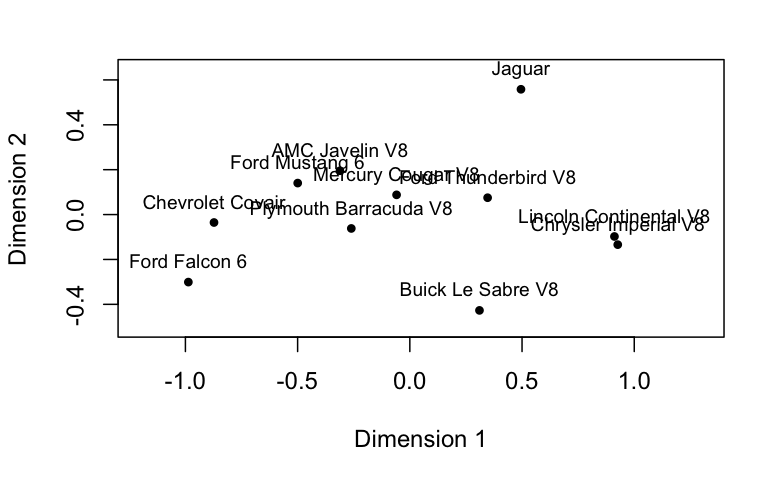

```r
plot(fit2,xlim=c(-1.2,1.3),main="",cex=1)
```

# Example 3 (Newspaper data)

- Using `mdpref` data because data structure is preference type
- Larger number is higher preference, lower is lesser preference

```r
newspaper<-read.csv("~/MSTAT/STAT8019_Marketing_Analytics/lecture notes/chap4r/newspaper1t.csv", header = TRUE,row.names=1)
newspaper
```

|  | subj1 | subj2 | subj3 | subj4 |
| --- | --- | --- | --- | --- |
| Boston Herald | 5 | 4 | 5 | 2 |
| New York Daily News | 3 | 5 | 4 | 1 |
| New York Post | 4 | 3 | 3 | 3 |
| New York Times | 1 | 2 | 1 | 5 |
| Boston Globe | 2 | 1 | 2 | 4 |

## `cmdpref` model

```r
fit<-cmdpref(newspaper,monotone=T)

fit
```

```
$score
                          dim1       dim2
Boston Herald       -1.0217029  0.8905619
New York Daily News -0.8740868 -1.4711179
New York Post       -0.1571822  0.6602885
New York Times       1.1997526 -0.5892077
Boston Globe         0.8532193  0.5094752

$corr
            dim1       dim2
subj1 -0.8686426  0.4954392
subj2 -0.9162677 -0.4005664
subj3 -0.9876468  0.1566968
subj4  0.9746422  0.2237689

$fitted
                          subj1      subj2      subj3        subj4
Boston Herald        1.32871395  0.5794242  1.1486297 -0.796514729
New York Daily News  0.03041951  1.3901779  0.6327695 -1.181112268
New York Post        0.46366796 -0.1204684  0.2587056 -0.005444418
New York Times      -1.33407280 -0.8632777 -1.2772587  1.037483161
Boston Globe        -0.48872863 -0.9858560 -0.7628461  0.945588254

$d
[1] 3.752045e+00 1.386420e+00 1.630099e-16 1.202229e-16

$tpref
                          subj1      subj2      subj3        subj4
Boston Herald        1.32871395  0.5794242  1.1486297 -0.796514729
New York Daily News  0.03041951  1.3901779  0.6327695 -1.181112268
New York Post        0.46366796 -0.1204684  0.2587056 -0.005444418
New York Times      -1.33407280 -0.8632777 -1.2772587  1.037483161
Boston Globe        -0.48872863 -0.9858560 -0.7628461  0.945588254
attr(,"scaled:center")
subj1 subj2 subj3 subj4
    3     3     3     3
attr(,"scaled:scale")
   subj1    subj2    subj3    subj4
1.581139 1.581139 1.581139 1.581139

attr(,"class")
[1] "mdpref"
```

```r
summary(fit)
```

```
Object coordinates
                       dim1    dim2
Boston Herald       -1.0217  0.8906
New York Daily News -0.8741 -1.4711
New York Post       -0.1572  0.6603
New York Times       1.1998 -0.5892
Boston Globe         0.8532  0.5095

Subject vectors
         dim1    dim2
subj1 -0.8686  0.4954
subj2 -0.9163 -0.4006
subj3 -0.9876  0.1567
subj4  0.9746  0.2238

Variation explained
            dim1     dim2
Sing.val  3.7520   1.3864
Val.exp  14.0778   1.9222
%        87.9865  12.0135
Cum%     87.9865 100.0000
```

## Perceptual Map

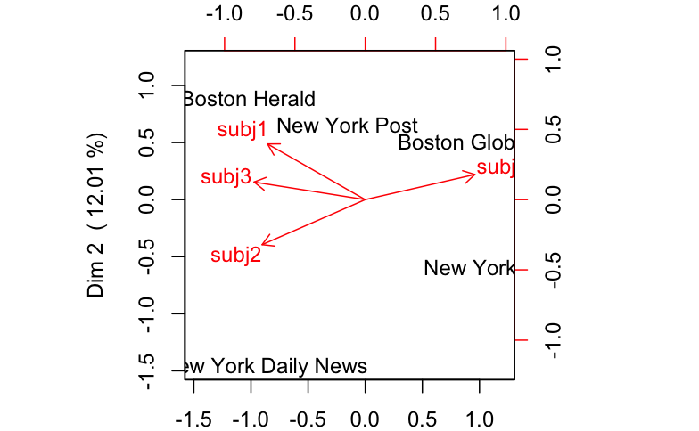

```r
par(mar=c(2,1,2,1))
plot(fit)
```

- Dimension 1 splits by global vs local
  - global - NYT, BG
  - local - BH, NYP, NYDW
- Dimension 2 , some difference between BH, NYP, BG vs NYT, NYDN
- Each newspaper are far from one another, so no keen competition

# Example 4 (Breakfast Data)

- Using `mdpref` model

```r
breakfast<-read.csv("~/MSTAT/STAT8019_Marketing_Analytics/lecture notes/chap4r/b1.csv", header = TRUE,row.names = 2)
head(breakfast[,1:7])
```

|  | X_NAME_ | COL1 | COL2 | COL3 | COL4 | COL5 | COL6 |
| --- | --- | --- | --- | --- | --- | --- | --- |
| Blueberry muffin and margarine | BMM | 12 | 14 | 14 | 12 | 8 | 11 |
| Buttered toast | BT | 4 | 6 | 7 | 2 | 4 | 14 |
| Buttered toast and jelly | BTJ | 6 | 9 | 9 | 4 | 13 | 10 |
| Cinnamon bun | CB | 14 | 15 | 5 | 9 | 9 | 5 |
| Coffee cake | CC | 7 | 11 | 13 | 13 | 15 | 4 |
| Corn muffin and butter | CMB | 2 | 3 | 11 | 6 | 2 | 13 |

## `mdpref` Model

- Set `monotone=T` because it is rank data (ordinal)

```r
fit<-cmdpref(breakfast[,2:22],monotone=T,maxit=100)
summary(fit)
```

```
Object coordinates
                                  dim1    dim2
Blueberry muffin and margarine -0.5498  0.3817
Buttered toast                  0.3982  0.9865
Buttered toast and jelly        0.0753  1.0115
Cinnamon bun                   -0.7809 -0.8007
Coffee cake                    -0.8644 -0.0922
Corn muffin and butter          0.1092  0.5186
Cinnamon toast                 -0.3806  0.2938
Danish pastry                  -1.1640 -0.8013
English muffin and margarine    0.1271  1.0072
Glazed donut                   -0.8279 -1.3501
Hard rolls and butter           0.7899  0.7033
Jelly donut                    -0.7422 -1.4836
Toast and marmalade             0.3871  0.9247
Toast and margarine             0.5324  0.5705
Toast pop-up                    2.8905 -1.8702

Subject vectors
         dim1    dim2
COL1  -0.6768 -0.5505
COL2  -0.8975  0.3903
COL3  -0.8390  0.5076
COL4  -0.7241 -0.4952
COL5  -0.9087  0.3676
COL6   0.6150  0.7337
COL7  -0.6925 -0.1937
COL8  -0.7379 -0.5999
COL9  -0.6941 -0.6525
COL10 -0.0914 -0.9231
COL11  0.1978  0.6986
COL12 -0.7485  0.2940
COL13 -0.8397  0.4805
COL14  0.3103  0.9028
COL15 -0.8560  0.4454
COL16 -0.0869  0.6685
COL17 -0.8040  0.5432
COL18 -0.6834  0.6946
COL19  0.7217  0.4577
COL20  0.4358 -0.3508
COL21  0.2903  0.6622

Variation explained
             dim1    dim2
Sing.val  11.3856  9.9848
Val.exp  129.6312 99.6955
%         44.0923 33.9100
Cum%      44.0923 78.0023
```

## Perceptive Map

- Major finding for the MDS is the plot
- Subjectively interpret

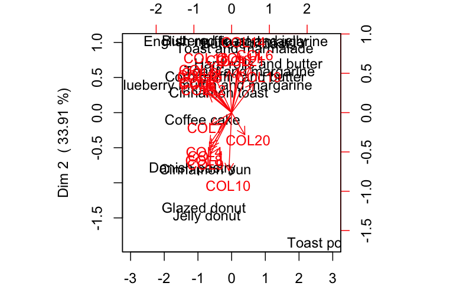

```r
par(mar=c(2,1,2,1))
plot(fit, xlim=c(-3, 3))
```

- Dim 1 separates the simple-soft vs toasted-hard
- Dim 2 separates the simple-hard vs soft-toasted

4 Major Segments

- Simple
- Hard
- Toasted
- Soft

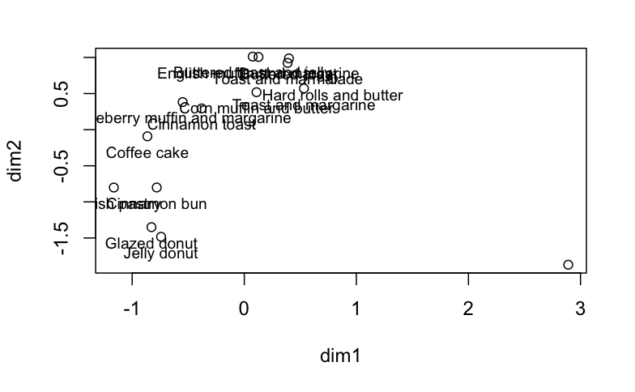

```r
#object plot
plot(fit$score)
text(fit$score,labels=rownames(fit$score),cex=0.8,pos=1)
```

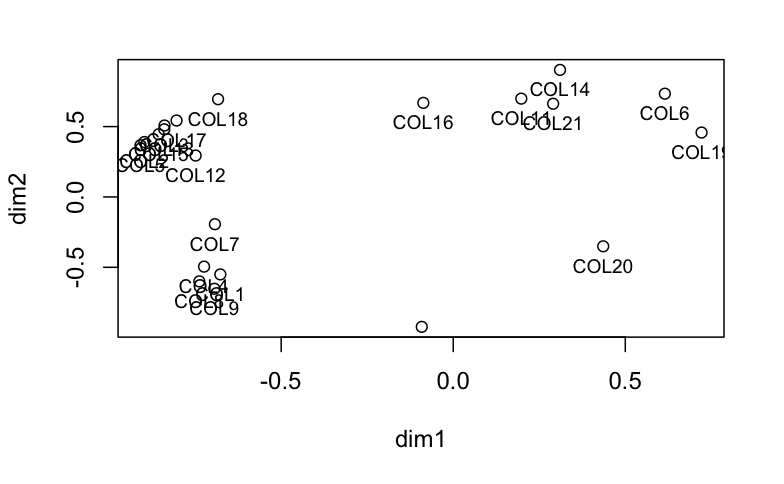

```r
#subject plot
plot(fit$corr)
text(fit$corr,labels=rownames(fit$corr),cex=0.8,pos=1)
```

- MDS gives subjective segment and positioning
- MAjor result is the graph to interpret